# MScA, Linear and Non-Linear Models (31010) Week 10 Workshop

© Yuri Balasanov, iLykei 2016

# 1 1. Markov Chains

## 1.1 Animation of 4-state Markov chain

The following code creates animation of Markov chain with 4 states for a given matrix of transition probabilities.  
Make sure you create the MC.Matrix with required transition probabilities before running this code.

```r
library(animation)
lambda=5
oopt = ani.options(interval = .5, nmax = 25) ## set some options first
MC.Matrix<-rbind(
  From.Pos1=c(To.Pos1=0,To.Pos2=0,To.Pos3=0,To.Pos4=0), ## Create Transition Probabilities Matix
  From.Pos2=c(To.Pos1=0,To.Pos2=0,To.Pos3=0,To.Pos4=0),
  From.Pos3=c(To.Pos1=0,To.Pos2=0,To.Pos3=0,To.Pos4=0),
  From.Pos4=c(To.Pos1=0,To.Pos2=0,To.Pos3=0,To.Pos4=0))
Current.State<-2
From.To<-rep(Current.State,2)

my.Data<-as.matrix(t(c(0,2)))   ## use loop to create images one by one
for (i in 1:ani.options("nmax")) {
  From.To[1]<-Current.State
  From.To[2]<-sample(1:4,1,prob=MC.Matrix[From.To[1],])
  Current.State<-From.To[2]

  wait.next<-rexp(1,lambda)
  my.Data<-rbind(my.Data,c(my.Data[length(my.Data[,1]),1]+1,From.To[2]))
  plot(my.Data,type="s",xlim=c(1,25),ylim=c(0,4),xlab="Time",ylab="State",lwd=3)
  abline(h=1,col="red")
  abline(h=4,col="red")
  ani.pause(wait.next)    ## pause for a while ('interval')

}

ani.options(oopt)   ## restore the options
```

```r
library(knitr)
```

### 1.1.1 Transition matrix 1

Create animation of Markov chain with the following transition probabilities matrix. Run it several times. What kind of behavior do you see?

```r
MC.Matrix<-data.frame(rbind(From.Pos1=c(To.Pos1=1,To.Pos2=0,To.Pos3=0,To.Pos4=0),
                 From.Pos2=c(To.Pos1=.03,To.Pos2=0,To.Pos3=.97,To.Pos4=0),
                 From.Pos3=c(To.Pos1=0,To.Pos2=.97,To.Pos3=0,To.Pos4=.03),
                 From.Pos4=c(To.Pos1=0,To.Pos2=0,To.Pos3=0,To.Pos4=1)))
kable(MC.Matrix)
```

|  | To.Pos1 | To.Pos2 | To.Pos3 | To.Pos4 |
| --- | --- | --- | --- | --- |
| From.Pos1 | 1.00 | 0.00 | 0.00 | 0.00 |
| From.Pos2 | 0.03 | 0.00 | 0.97 | 0.00 |
| From.Pos3 | 0.00 | 0.97 | 0.00 | 0.03 |
| From.Pos4 | 0.00 | 0.00 | 0.00 | 1.00 |

### 1.1.2 Transition matrix 2

Create animation of Markov chain with the following transition probabilities matrix. Run it several times. What kind of behavior do you see?

|  | To.Pos1 | To.Pos2 | To.Pos3 | To.Pos4 |
| --- | --- | --- | --- | --- |
| From.Pos1 | 0.00 | 0.85 | 0.10 | 0.05 |
| From.Pos2 | 0.30 | 0.00 | 0.70 | 0.00 |
| From.Pos3 | 0.00 | 0.70 | 0.00 | 0.30 |
| From.Pos4 | 0.05 | 0.10 | 0.85 | 0.00 |

### 1.1.3 Transition matrix 3

Create animation of Markov chain with the following transition probabilities matrix. Run it several times. What kind of behavior do you see?

|  | To.Pos1 | To.Pos2 | To.Pos3 | To.Pos4 |
| --- | --- | --- | --- | --- |
| From.Pos1 | 0.0 | 0.9 | 0.0 | 0.1 |
| From.Pos2 | 0.1 | 0.0 | 0.9 | 0.0 |
| From.Pos3 | 0.0 | 0.1 | 0.0 | 0.9 |
| From.Pos4 | 0.9 | 0.0 | 0.1 | 0.0 |

# 2 Fitting Hidden Markov Models

The package for Hidden Markov Models (HMM) is `depmixS4`.

```r
library(depmixS4)
```

## 2.1 Modeling of Cognitive Processes Literature

Gilles Dutilh, Eric-Jan Wagenmakers, Ingmar Visser, Han L. J. van der Maas, A Phase Transition Model for the Speed-Accuracy Trade-Off in Response Time Experiments, Cognitive Science 35 (2011) 211–250, 2010 Cognitive Science Society, Inc.

Ingmar Visser, Seven things to remember about hidden Markov models: A tutorial on Markovian models for time series, Journal of Mathematical Psychology, 55, (2011), 403–415

## 2.2 The Speed-Accuracy Trade-Off in Response Time Experiment

The description of the problem below is from the article by Ingmar Visser.

The data are from consecutive lexical decision trials, in which the participant had to decide whether the presented sequence of letters formed a word or not.  
The data that are analyzed here are from participant A in Experiment 1 in the article by Dutilh etal.  
Each trial resulted in recording of response time and accuracy of answers.  
To manipulate the accuracy and response times, there was a dynamic pay-off for accuracy of answers.  
The pay-off for speed was determined as 1 minus the pay-off for accuracy.  
The pay-off for accuracy was varied continuously in a zigzag manner, and there were 6 maxima for the pay-off for accuracy during 168 trials.

The participant was shown the reward after each trial, so that it affected behavior in future trial.  
The response times(RT), accuracy (ACC), and the pay-off for accuracy (Pacc) are in the corresponding columns of the data.

The most striking feature of these data, and in particular the response times, is their seemingly periodic nature, and the goal of modeling is to capture this feature.  
The periodicity of the data is clearly related to the pay-off for speed and accuracy, as shown by the correlations between the variables.

The key question about these data is what effect the (continuous) changes in pay-off for speed and accuracy have on the results of the experiment.

- The first hypothesis states that continuous changes in pay-off should result in continuous changes in speed and accuracy.
- Alternatively, the second hypothesis states that the changes in pay-off may result in switching between two modes of responding: one slow and accurate, and another with fast responses and accuracy at chance level.  
  Hence, the second hypothesis states that continuous changes in pay-off should result in discontinuous changes in speed and accuracy.

In order to test the hypotheses above, the following models need to be compared:

1. a 1-state model with the pay-off for accuracy as a predictor for response time and accuracy;
2. a 2-state model with switching between the states.

The 2-state model can be further elaborated by making the transition probabilities depend on the pay-off for accuracy.

Note that the 1-state model is not a proper hidden Markov model because it has only a single state, which is, as a consequence not hidden, and moreover there is no dynamic part in the model because the transition matrix consists only of a single element equal to 1.

The 1-state model is in effect a multiple regression model for the response time and accuracy and it is specified by the following equations:

$$RT_t=\mu+\beta Pacc_t+\epsilon_t,$$
with $\epsilon_t$ distributed as $Norm(0,\sigma^2)$ $ACC_t$ is a Bernoulli variable with probability of success $p_t,$, with
$$logit(p_t)=b_0+b_1 Pacc_t$$
.

Here $RT_t$ are the response times and $ACC_t$ are the accuracy values; $Pacc_t$ represents the pay-off for accuracy, scaled from 0 to 1, with 1 representing the maximum reward for accuracy, and no reward for speed; conversely, $Pacc_t=0$ means no reward for accuracy, and maximum reward for speed.

For the RT variable, the parameters of the model are: the mean response time $\mu$, the regression coefficient $\beta$ relating the pay-off for accuracy to response time, and the standard deviation $\sigma$.  
For the ACC variable, the parameters of the model are the coefficients $b_0$ and $b_1$, where $b_1$ relates $Pacc_t$ to the logit of the probability

$$P(ACC_t=1)=p_t.$$

The second hypothesis states that there are two modes of behavior, and that the participant switches between these over the series of trials.  
Such a hypothesis is naturally captured by a 2-state HMM.

The 2-state HMM is defined by the state dependent means and standard deviations of the RT variable and the state dependent probabilities for the ACC variable, i.e., $P(ACC_t=1)$, as follows:

$$RT_t=\mu_i+\epsilon_t,$$
with $\epsilon$ distributed as normal with mean 0 and std. $\sigma^2_i$, $i=1,2$.

$ACC_t$ is distributed as $Bernoulli(p_i), i=1,2$.

For modeling RT then, the parameters of this model are the state dependent means $\mu_i$ and standard deviations $\sigma_i$.

For ACC, the parameters are the state dependent Bernoulli probabilities $p_i$.

After defining states with these parameters, estimate transition matrix A and the initial state probability vector $\pi$.  
Note that the variable Pacc has no role in the 2-state model described here.

In the 1-state model, the assumption is that Pacc influences response times and accuracy directly.

In the 2-state model, the core assumption is that there are two modes of behavior, slow and accurate versus fast guessing behavior, and that switching between these modes of behavior is influenced by the pay-off for accuracy.

Hence, Pacc is hypothesized to have an indirect influence on RT and ACC through the state variables.  
This hypothesis can also be expressed within the framework of hidden Markov models by including Pacc as a covariate on the transition probabilities. That is, the transition probabilities are modeled as a function of Pacc.  
The third model that is fitted to the data incorporates this idea.

The measurement equations, i.e., the equations that relate the hidden states to the observed variables, of the third model are identical to those of the 2-state model."

## 2.3 Data Analysis

Look at the data:

```r
data(speed)
head(speed)
```

```
##         rt corr Pacc prev
## 1 6.456770  cor    0  inc
## 2 5.602119  cor    0  cor
## 3 6.253829  inc    0  cor
## 4 5.451038  inc    0  inc
## 5 5.872118  inc    0  inc
## 6 6.003887  cor    0  inc
```

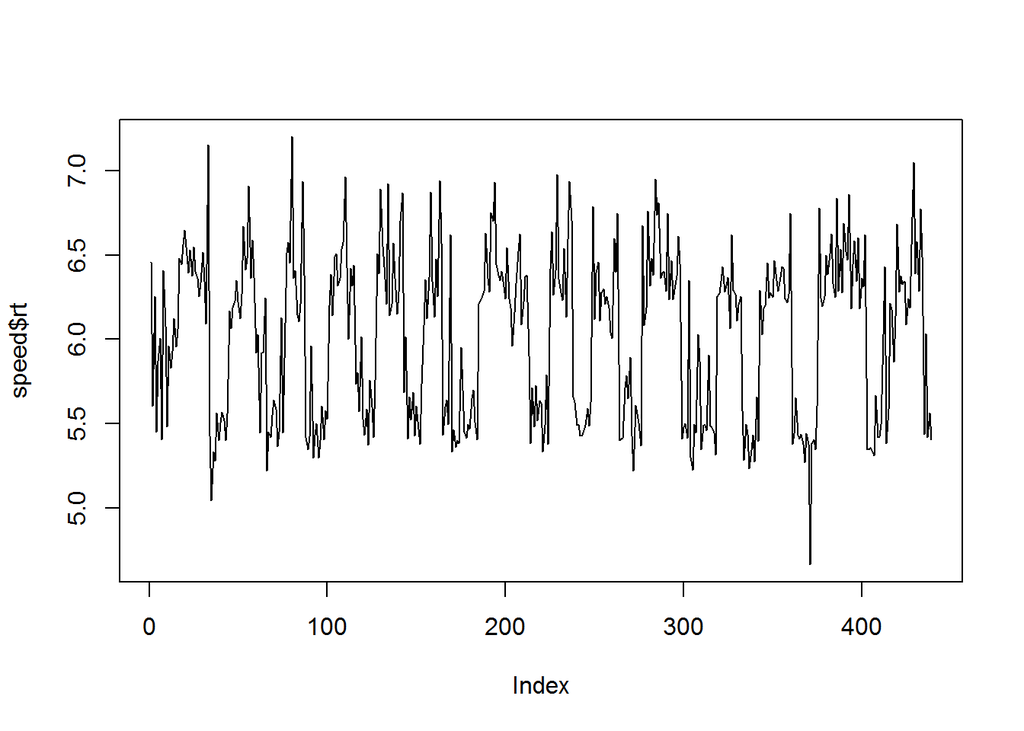

```r
plot(speed$rt,type="l",lty=1)
```

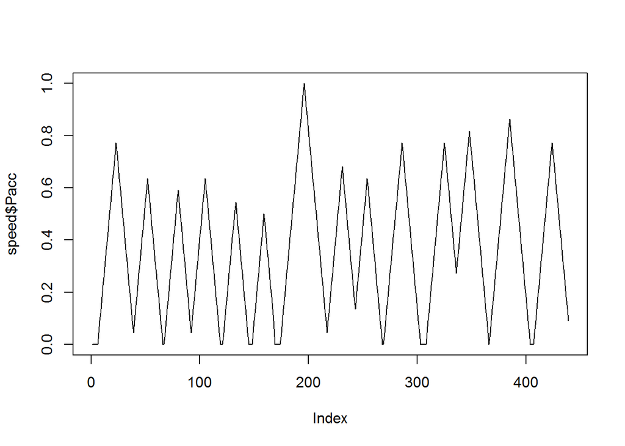

```r
plot(speed$Pacc,type="l",lty=1)
```

Select the first series of trials

```r
sp1 <- data.frame(speed[1:168,])
names(sp1) <- c("RT", "ACC","Pacc")
```

Check the distribution of response time.

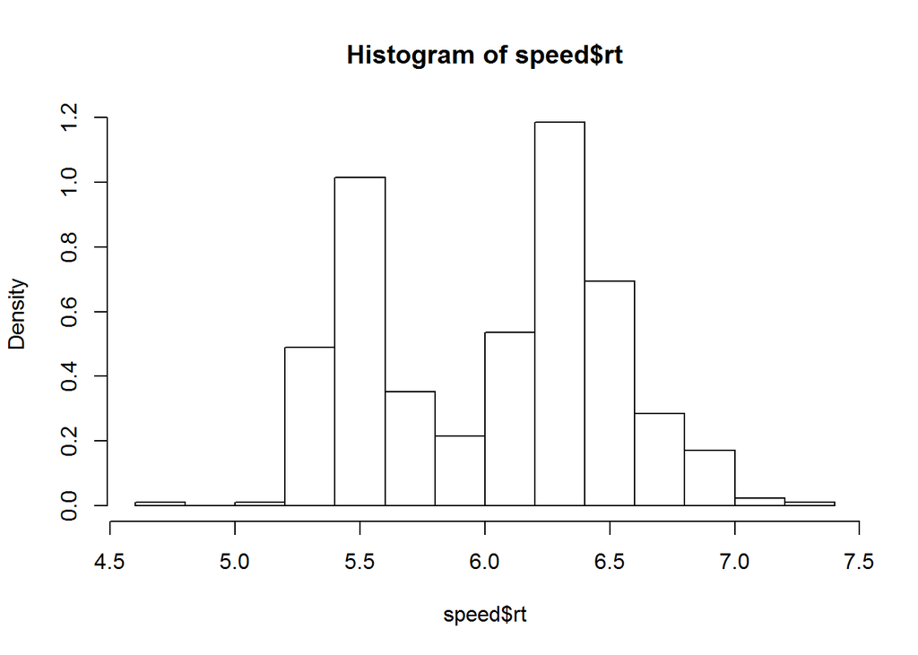

```r
speed.rt.hist<-hist(speed$rt,freq=FALSE)
```

The bi-modal distribution is a sign of mixture of two different modes.

### 2.3.1 One-State Model for Response Time

Fit the one component model

$$RT_t = \mu + \epsilon_t, \epsilon_t \sim N(0,\sigma^2).$$
First, create the mix model using `mix()`.

The fundamental assumption of a dependent mixture model is that at any time point, the observations are distributed as a mixture with $n$ components (or states), and that time-dependencies between the observations are due to time-dependencies between the mixture components (i.e., transition probabilities between the components).  
These latter dependencies are assumed to follow a first-order Markov process: dependence of futures state on $k=1$ previous states.  
In the models we are considering here, the mixture distributions, the initial mixture probabilities and transition probabilities can all depend on covariates $z_t$.

Then fit the mix model.

```r
set.seed(6)
m1 <- mix(RT~1,nstates=1, data=sp1)
(fm1 <- fit(m1))
```

```
## iteration 0 logLik: -114.6113
## converged at iteration 1 with logLik: -114.6113
```

```
## Convergence info: Log likelihood converged to within tol. (relative change)
## 'log Lik.' -114.6113 (df=2)
## AIC:  233.2225
## BIC:  239.4705
```

Take a note of the goodness of fit characteristics `AIC` and `BIC`. Check the summary.

```r
summary.fm1<-summary(fm1)
```

```
## Mixture probabilities model
## pr1
##   1
##
## Response parameters
## Resp 1 : gaussian
##     Re1.(Intercept)    Re1.sd
## St1        6.035737 0.4786773
```

Since 1-state model is not really an HMM the summary only gives us the mean and the standard deviation of the variable `RT`.

Plot the histogram again with the distribution of the single state of the estimated model.

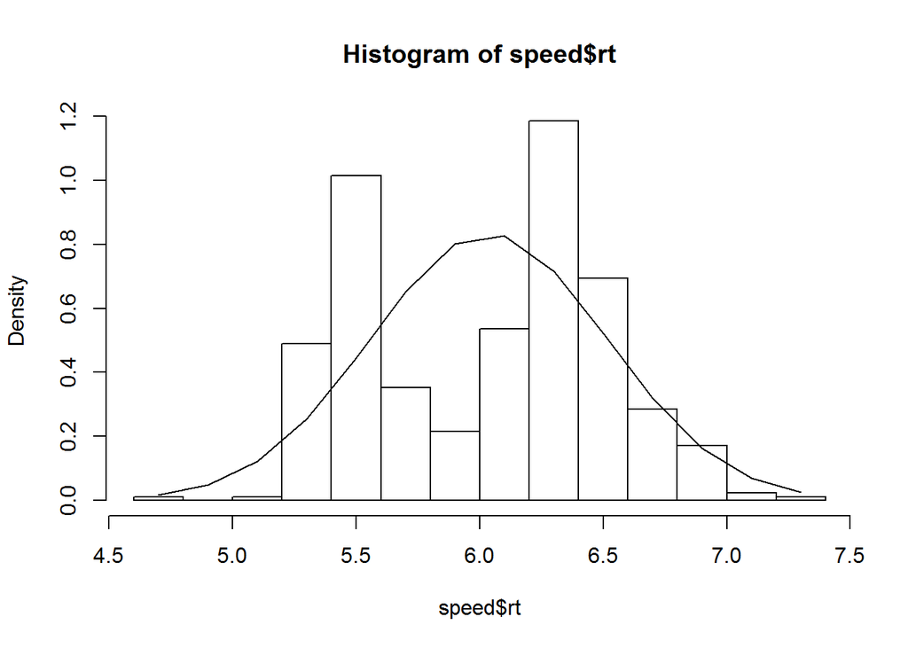

```r
plot(speed.rt.hist,freq=FALSE)
lines(speed.rt.hist$mids,dnorm(speed.rt.hist$mids,summary.fm1[1],summary.fm1[2]))
```

### 2.3.2 Two-State Model for Response Time

Fit a two-component model for `RT`:

State 1: $RT_t = \mu_1 + \epsilon_{t,1}, \epsilon_{t,1} \sim N(0,\sigma^2_1);$  
State 2: $RT_t = \mu_2 + \epsilon_{t,2}, \epsilon_{t,2} \sim N(0,\sigma^2_2).$

For that create a two-state model first.  
Explore the `S4` object of the fitted model.

```r
set.seed(1)
# Create the object with 2 states
m2 <- mix(RT~1,nstates=2, data=sp1,respstart=c(rnorm(1,5),1,rnorm(1,6),1))
(fm2 <- fit(m2,emcontrol=em.control(rand=F)))
```

```
## iteration 0 logLik: -114.1006
## iteration 5 logLik: -110.6488
## iteration 10 logLik: -87.89717
## iteration 15 logLik: -87.60607
## iteration 20 logLik: -87.54278
## iteration 25 logLik: -87.46804
## iteration 30 logLik: -87.44245
## iteration 35 logLik: -87.43871
## iteration 40 logLik: -87.43831
## iteration 45 logLik: -87.43828
## converged at iteration 47 with logLik: -87.43828
```

```
## Convergence info: Log likelihood converged to within tol. (relative change)
## 'log Lik.' -87.43828 (df=5)
## AIC:  184.8766
## BIC:  200.4964
```

```r
summary.fm2<-summary(fm2)
```

```
## Mixture probabilities model
##       pr1       pr2
## 0.3314427 0.6685573
##
## Response parameters
## Resp 1 : gaussian
##     Re1.(Intercept)    Re1.sd
## St1        5.475247 0.1255537
## St2        6.313604 0.3193105
```

```r
summary.fm2
```

```
##     Re1.(Intercept)    Re1.sd
## St1        5.475247 0.1255537
## St2        6.313604 0.3193105
```

```r
getpars(fm2)
```

```
##         pr1         pr2 (Intercept)          sd (Intercept)          sd
##   0.3314427   0.6685573   5.4752471   0.1255537   6.3136037   0.3193105
```

Parameter `respstart` sets randomly selected initial guesses.  
Note that `AIC` and `BIC` are better for the 2-state model.  
The summary gives the means and standard deviations of the two normal distributions as the states of the model.

Plot the fitted mix.

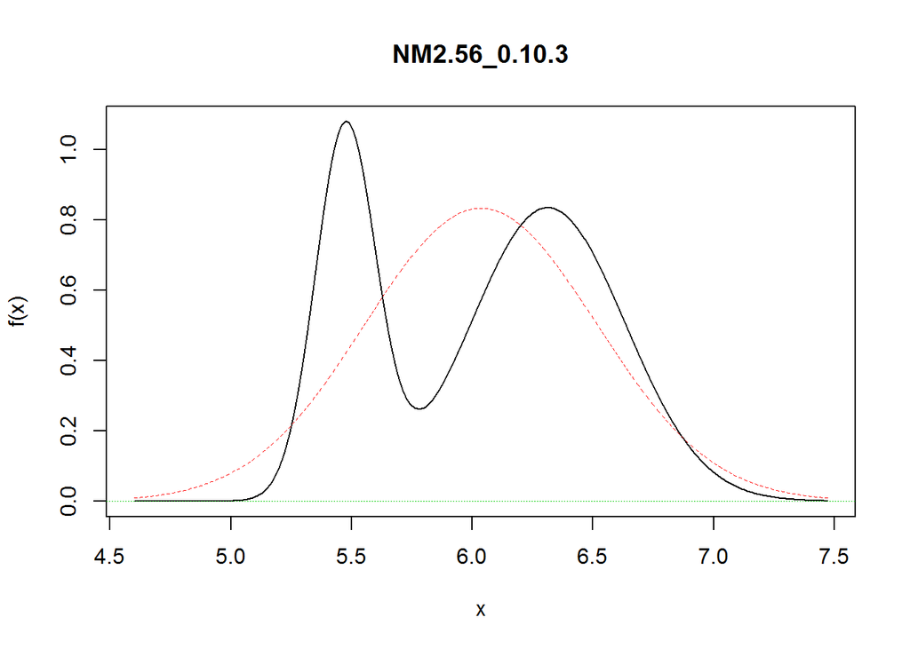

```r
library(nor1mix)
Two.State.mix<-norMix(mu=summary.fm2[,1],sigma=summary.fm2[,2],w=getpars(fm2)[1:2])
plot(Two.State.mix)
```

### 2.3.3 One-State Model for Both Accuracy and Response Time with Payoff as Predictor

Fit a 1-state model for both variables: binomial for accuracy $Acc$ and Gaussian for response time $RT$; for both `Pacc` is the predictor:

$$RT_t = \beta_0 + \beta_1 Pacc_t + \epsilon_{t,RT},~\epsilon_{t,RT} \sim N(0,\sigma^2_{RT});$$
$$ACC_t \sim Binomial(p_t);~logit(p_t) = \gamma_0 + \gamma_1 Pacc_t.$$

```r
m1p <- depmix(list(ACC~Pacc,RT~Pacc), nstates=1,data=sp1,family=list(multinomial(),gaussian()))
(fm1p <- fit(m1p))
```

```
## iteration 0 logLik: -144.6998
## converged at iteration 1 with logLik: -144.6998
```

```
## Convergence info: Log likelihood converged to within tol. (relative change)
## 'log Lik.' -144.6998 (df=5)
## AIC:  299.3995
## BIC:  315.0194
```

```r
summary(fm1p)
```

```
## Initial state probabilties model
## pr1
##   1
##
## Transition matrix
##        toS1
## fromS1    1
##
## Response parameters
## Resp 1 : multinomial
## Resp 2 : gaussian
##     Re1.(Intercept).inc Re1.(Intercept).cor Re1.Pacc.inc Re1.Pacc.cor
## St1                   0              -0.441            0        6.645
##     Re2.(Intercept) Re2.Pacc Re2.sd
## St1           5.562    1.575  0.367
```

Extract the estimated transition matrix.

```r
fm1p@transition
```

```
## [[1]]
## Model of type multinomial (identity), formula: ~1
## <environment: 0x06b90e1c>
## Coefficients:
## [1] 1
```

In this case the result is trivial: there is only one state.

Compare `AIC` and `BIC` with previous models.

```r
rbind(AIC=c(fm1=AIC(fm1),fm2=AIC(fm2),fm1p=AIC(fm1p)),BIC=c(fm1=BIC(fm1),fm2=BIC(fm2),fm1p=BIC(fm1p)))
```

```
##          fm1      fm2     fm1p
## AIC 233.2225 184.8766 299.3995
## BIC 239.4705 200.4964 315.0194
```

### 2.3.4 Two-State Model for Both Accuracy and Response Time with no Predictors

Fit a 2-state model with intercept only and Gaussian and multinomial distributions for `RT` and `ACC` correspondingly:

State 1:  
$RT_t = \mu_1 + \epsilon_{t,1}, \epsilon_{t,1} \sim N(0,\sigma^2_1);$  
$ACC_t \sim Binomial(p_1);$  
State 2:  
$RT_t = \mu_2 + \epsilon_{t,2}, \epsilon_{t,2} \sim N(0,\sigma^2_2);$  
$ACC_t \sim Binomial(p_2).$

(Skipped Code)

```
## iteration 0 logLik: -206.784
## iteration 5 logLik: -205.6599
## iteration 10 logLik: -146.823
## iteration 15 logLik: -128.1188
## iteration 20 logLik: -128.1177
## converged at iteration 22 with logLik: -128.1177
```

```r
summary(fm2p)
```

```
## Initial state probabilties model
## pr1 pr2
##   0   1
##
## Transition matrix
##         toS1  toS2
## fromS1 0.912 0.088
## fromS2 0.093 0.907
##
## Response parameters
## Resp 1 : gaussian
## Resp 2 : multinomial
##     Re1.(Intercept) Re1.sd Re2.(Intercept).inc Re2.(Intercept).cor
## St1           5.617  0.260                   0               0.277
## St2           6.426  0.254                   0               2.789
```

```r
getmodel(fm2p,which="response",state=1,number=1) # state 1, model 1
```

```
## Model of type gaussian (identity), formula: RT ~ 1
## Coefficients:
## (Intercept)
##    5.617441
## sd  0.2600164
```

```r
getmodel(fm2p,which="response",state=1,number=2) # state 1, model 2
```

```
## Model of type multinomial (mlogit), formula: ACC ~ 1
## Coefficients:
##             inc      cor
## (Intercept)   0 0.276966
## Probalities at zero values of the covariates.
## 0.4311978 0.5688022
```

Reproduce probabilities at zero values of covariates:

```r
c(1-exp(0.276966)/(1+exp(0.276966)),exp(0.276966)/(1+exp(0.276966)))
```

```
## [1] 0.4311978 0.5688022
```

```r
getmodel(fm2p,which="response",state=2,number=1) # state 2, model 1
```

```
## Model of type gaussian (identity), formula: RT ~ 1
## Coefficients:
## (Intercept)
##    6.426016
## sd  0.2535086
```

```r
getmodel(fm2p,which="response",state=2,number=2) # state 2, model 2
```

```
## Model of type multinomial (mlogit), formula: ACC ~ 1
## Coefficients:
##             inc      cor
## (Intercept)   0 2.788936
## Probalities at zero values of the covariates.
## 0.05792501 0.942075
```

Again, reproduce probabilities at zero values of covariates.

```r
c(1-exp(2.788936)/(1+exp(2.788936)),exp(2.788936)/(1+exp(2.788936)))
```

```
## [1] 0.05792499 0.94207501
```

Plot the estimated state intercepts.

```r
getpars(fm2p,which="pars",state=1,number=1)[c(7,11)]
```

```
## (Intercept) (Intercept)
##    5.617441    6.426016
```

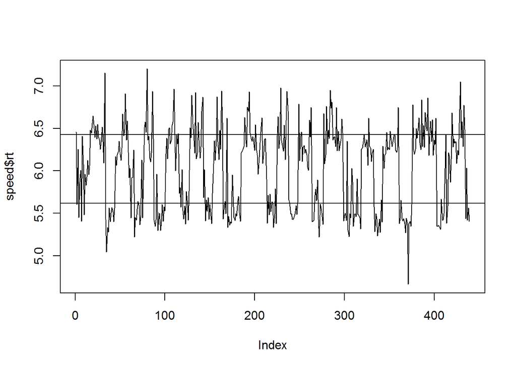

```r
plot(speed$rt,type="l",lty=1)
abline(h=getpars(fm2p,which="pars",state=1,number=1)[7])
abline(h=getpars(fm2p,which="pars",state=1,number=1)[11])
```

**Interpret the estimated transition matrix.** **Figure out meanings of parameters**.

(Skipped Code)

```
##             pr1             pr2
##      0.00000000      1.00000000      0.91161672      0.08838328
##                                     (Intercept)              sd
##      0.09295066      0.90704934      5.61744069      0.26001643
## (Intercept).inc (Intercept).cor     (Intercept)              sd
##      0.00000000      0.27696601      6.42601607      0.25350855
## (Intercept).inc (Intercept).cor
##      0.00000000      2.78893564
```

### 2.3.5 Two-State Model for Both Accuracy and Response Time, No Predictors, Transition Probabilities Dependent on Payoff

Fit a model with intercepts only for Gaussian `RT` and multinomial `ACC`, making transition probabilities dependent on `Pacc`:

State 1:  
$RT_t = \mu_1 + \epsilon_{t,1},~\epsilon_{t,1} \sim N(0,\sigma^2_1);$  
$ACC_t \sim Binomial(p_1);$  
State 2:  
$RT_t = \mu_2 + \epsilon_{t,2},~\epsilon_{t,2} \sim N(0,\sigma^2_2);$  
$ACC_t \sim Binomial(p_2).$  
Dependence of transition probabilities is described by logistic regressions:

$$logit(1-a_{1,1}(t)) = \beta_{1,0} + \beta_{1,1} Pacc_t,$$
$$logit(a_{2,2}(t)) = \beta_{2,0} + \beta_{2,1} Pacc_t,$$
where $a_{i,j}$ is the transition probability from state $i$ to state $j$.
If the model has more than 2 states then logistic regression model will be replaced with multinomial logistic regression.

```r
set.seed(1)
m2a <- depmix(list(RT~1,ACC~1),nstates=2, data=sp1,family=list(gaussian(),multinomial()),transition=~Pacc)
(fm2a <- fit(m2a))
```

```
## iteration 0 logLik: -206.6387
## iteration 5 logLik: -141.1648
## iteration 10 logLik: -107.2242
## iteration 15 logLik: -107.1984
## iteration 20 logLik: -107.1966
## converged at iteration 24 with logLik: -107.1966
```

```
## Convergence info: Log likelihood converged to within tol. (relative change)
## 'log Lik.' -107.1966 (df=11)
## AIC:  236.3932
## BIC:  270.7568
```

```r
summary(fm2a)
```

```
## Initial state probabilties model
## pr1 pr2
##   0   1
##
## Transition model for state (component) 1
## Model of type multinomial (mlogit), formula: ~Pacc
## Coefficients:
##             St1       St2
## (Intercept)   0 -7.798327
## Pacc          0 21.565175
## Probalities at zero values of the covariates.
## 0.9995897 0.0004102526
##
## Transition model for state (component) 2
## Model of type multinomial (mlogit), formula: ~Pacc
## Coefficients:
##             St1       St2
## (Intercept)   0 -4.483022
## Pacc          0 20.040962
## Probalities at zero values of the covariates.
## 0.988827 0.01117297
##
##
## Response parameters
## Resp 1 : gaussian
## Resp 2 : multinomial
##     Re1.(Intercept) Re1.sd Re2.(Intercept).inc Re2.(Intercept).cor
## St1           5.632  0.274                   0               0.286
## St2           6.431  0.253                   0               2.919
```

```r
getpars(fm2a)
```

```
##             pr1             pr2 (Intercept).St1 (Intercept).St2
##       0.0000000       1.0000000       0.0000000      -7.7983271
##        Pacc.St1        Pacc.St2 (Intercept).St1 (Intercept).St2
##       0.0000000      21.5651754       0.0000000      -4.4830219
##        Pacc.St1        Pacc.St2     (Intercept)              sd
##       0.0000000      20.0409621       5.6316966       0.2737131
## (Intercept).inc (Intercept).cor     (Intercept)              sd
##       0.0000000       0.2856490       6.4311117       0.2529209
## (Intercept).inc (Intercept).cor
##       0.0000000       2.9190830
```

Recall that this model has 2 states with a covariate effect on the transition probabilities.  
The parameters of this model are:

State 1: parameters for RT are $\mu_1 = 5.63, \sigma_1 = 0.274$;  
probability for Acc can be calculated from the odds ratio 0.285649 as  
$p_1 = \frac{exp(0.285649)}{1+exp(0.285649)} = 0.571.$  
This is the state of low accuracy and fast response.

State 2: parameters for RT are $\mu_2 = 6.43, \sigma_2 = 0.253$;  
probability for Acc can be calculated from the odds ratio 2.919083 as  
$p_2 = \frac{exp(2.919083)}{1+exp(2.919083)} = 0.949.$  
This is the state of high accuracy and slow response.

The parameters of most interest for this model are the transition model parameters.

The first logit regression model

$$logit(1-a_{1,1}(t)) = \beta_{1,0} + \beta_{1,1} Pacc_t$$
has estimated coefficients $\beta_{1,0} = -7.798327$ and $\beta_{1,1} = 21.565175$.
By inverting the logit transformation when $Pacc = 0$ find the probability $1-a_{1,1}(t)$ as
$$1-a_{1,1}(t) = \frac{exp(-7.798327)}{1+exp(-7.798327)} = 0.0004102527,$$
or $a_{1,1}(t) = 0.9995897.$

**Interpretation:** when subject is in low accuracy state and reward for accuracy Pacc is close to zero then the probability to stay in the same state $a_{1,1}(t) = 0.9995897$ is almost one.

The second logit regression model

$$logit(a_{2,2}(t)) = \beta_{2,0} + \beta_{2,1} Pacc_t$$
has estimated coefficients $\beta_{2,0} = -4.483022$ and $\beta_{2,1} = 20.040962$.
By inverting the logit transformation when $Pacc = 0$ find the probability $a_{2,2}(t)$ as
$$a_{2,2}(t) = \frac{exp(-4.483022)}{1+exp(-4.483022)} = 0.01117297,$$
or $1-a_{2,2}(t) = 0.988827.$

**Interpretation:** when subject is in high accuracy state and reward for accuracy Pacc is close to zero then the probability of staying in the same state $a_{2,2}(t) = 0.01117297$ is close to zero. Most likely the subject will move to low accuracy state 1: $1-a_{2,2}(t) = 0.988827$.

### 2.3.6 Three-State Model for Both Accuracy and Response Time, No Predictors

Fit a 3-state model with intercepts only for Gaussian `RT` and binomial `ACC`:

State 1:  
$RT_t = \mu_1 + \epsilon_{t,1}, \epsilon_{t,1} \sim N(0,\sigma^2_1);$  
$ACC_t \sim Binomial(p_1);$  
State 2:  
$RT_t = \mu_2 + \epsilon_{t,2}, \epsilon_{t,2} \sim N(0,\sigma^2_2;$  
$ACC_t \sim Binomial(p_2);$  
State 3:  
$RT_t = \mu_3 + \epsilon_{t,3}, \epsilon_{t,3} \sim N(0,\sigma^2_3;$  
$ACC_t \sim Binomial(p_3).$

(Skipped Code)

```
## iteration 0 logLik: -206.472
## iteration 5 logLik: -188.0143
## iteration 10 logLik: -124.7241
## iteration 15 logLik: -110.0541
## iteration 20 logLik: -109.3016
## iteration 25 logLik: -109.1369
## iteration 30 logLik: -109.1156
## iteration 35 logLik: -109.1132
## iteration 40 logLik: -109.113
## iteration 45 logLik: -109.1129
## converged at iteration 47 with logLik: -109.1129
```

```r
summary(fm3)
```

```
## Initial state probabilties model
## pr1 pr2 pr3
##   0   1   0
##
## Transition matrix
##         toS1  toS2  toS3
## fromS1 0.423 0.224 0.353
## fromS2 0.032 0.906 0.062
## fromS3 0.261 0.000 0.739
##
## Response parameters
## Resp 1 : gaussian
## Resp 2 : multinomial
##     Re1.(Intercept) Re1.sd Re2.(Intercept).inc Re2.(Intercept).cor
## St1           5.995  0.186                   0              -0.165
## St2           6.443  0.250                   0               3.102
## St3           5.474  0.125                   0               0.581
```

Compare the models and select the best one.

```r
(AIC.BIC.comparison<-rbind(AIC=c(fm1=AIC(fm1),
                                fm2=AIC(fm2),
                                fm1p=AIC(fm1p),
                                fm2p=AIC(fm2p),
                                fm2a=AIC(fm2a),
                                fm3=AIC(fm3)),
                          BIC=c(fm1=BIC(fm1),
                                fm2=BIC(fm2),
                                fm1p=BIC(fm1p),
                                fm2p=BIC(fm2p),
                                fm2a=BIC(fm2a),
                                fm3=BIC(fm3))))
```

```
##          fm1      fm2     fm1p     fm2p     fm2a      fm3
## AIC 233.2225 184.8766 299.3995 274.2353 236.3932 252.2259
## BIC 239.4705 200.4964 315.0194 302.3510 270.7568 305.3333
```

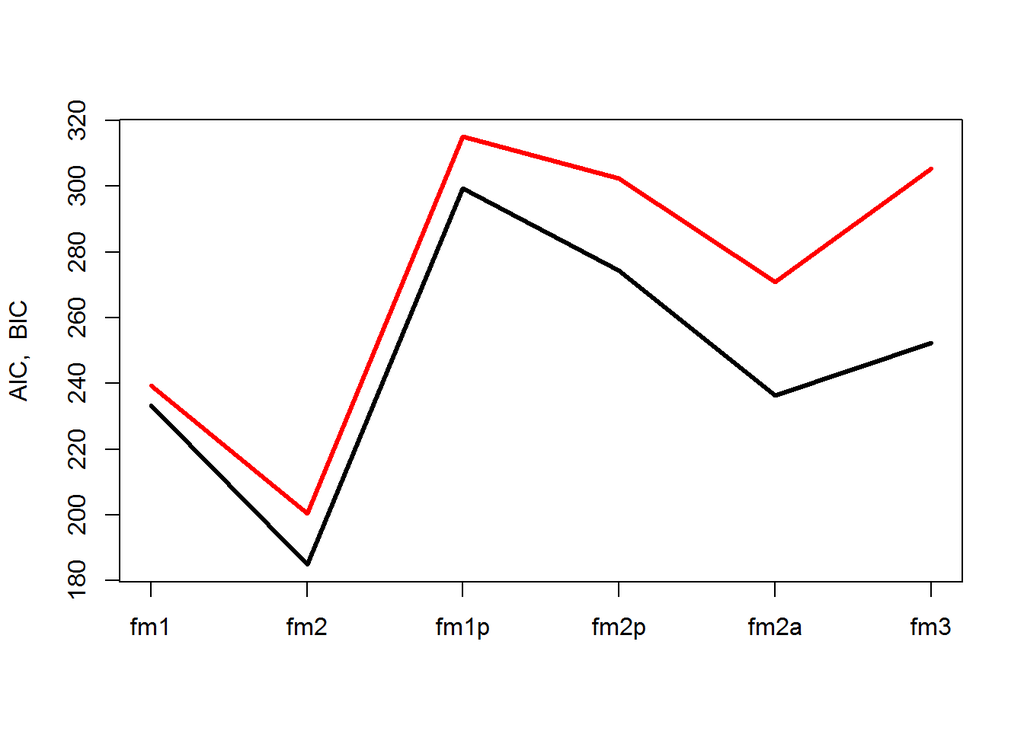

```r
matplot(t(AIC.BIC.comparison),type="l",lwd=3,lty=1,ylab="AIC,  BIC",xaxt="n",col=c("black","red"))
axis(1,at=1:6,labels=c("fm1","fm2","fm1p","fm2p","fm2a","fm3"))
```

```r
getpars(fm2)
```

```
##         pr1         pr2 (Intercept)          sd (Intercept)          sd
##   0.3314427   0.6685573   5.4752471   0.1255537   6.3136037   0.3193105
```

```r
getpars(fm2a)
```

```
##             pr1             pr2 (Intercept).St1 (Intercept).St2
##       0.0000000       1.0000000       0.0000000      -7.7983271
##        Pacc.St1        Pacc.St2 (Intercept).St1 (Intercept).St2
##       0.0000000      21.5651754       0.0000000      -4.4830219
##        Pacc.St1        Pacc.St2     (Intercept)              sd
##       0.0000000      20.0409621       5.6316966       0.2737131
## (Intercept).inc (Intercept).cor     (Intercept)              sd
##       0.0000000       0.2856490       6.4311117       0.2529209
## (Intercept).inc (Intercept).cor
##       0.0000000       2.9190830
```

**Conclusion:** The theory of continuous dependence of the trade off between speed and accuracy on the payoff does not seem to be correct.  
The best model explaining the data shows jumps between two states: Fast and wrong response, long and correct response.

# 3 Self Organizing Maps: Alternative Way of Decoding Markov Chain

[Ron Wehrens, Lutgarde M. C. Buydens, Self- and Super-organizing Maps in R: The kohonen Package, Journal of Statistical Software, Oct. 2007, V. 21, Issue 5](http://www.jstatsoft.org/v21/i05/paper)

The package for fitting SOM is `kohonen`.

```r
suppressWarnings(library(kohonen))
```

## 3.1 Self Organizing Map for Interest Rates Data

The data used in the course project for Statistical Analysis (31007) can be imported from the file `regressionassignmentdata2014.csv`.

```r
RatesData<-read.csv(paste(datapath,"regressionassignmentdata2014.csv",sep="/"),header=T,sep=",")
RatesData<-RatesData[,2:8]
RatesData[1:10,]
```

```
##    USGG3M USGG6M USGG2YR USGG3YR USGG5YR USGG10YR USGG30YR
## 1   13.52  13.09  12.289   12.28  12.294   12.152   11.672
## 2   13.58  13.16  12.429   12.31  12.214   12.112   11.672
## 3   14.50  13.90  12.929   12.78  12.614   12.382   11.892
## 4   14.76  14.00  13.099   12.95  12.684   12.352   11.912
## 5   15.20  14.30  13.539   13.28  12.884   12.572   12.132
## 6   15.22  14.23  13.179   12.94  12.714   12.452   12.082
## 7   15.24  14.10  13.309   12.97  12.684   12.532   12.082
## 8   15.08  13.90  12.959   12.75  12.614   12.532   12.072
## 9   15.25  14.09  13.259   13.02  12.774   12.622   12.252
## 10  15.15  13.98  13.089   12.85  12.664   12.532   12.132
```

```r
maturities<-c(.25,.5,2,3,5,10,30)
```

Create SOM using the 7 rates variables of the file.

```r
RatesData.som <- som(as.matrix(RatesData), grid = somgrid(3,3, "hexagonal"))
names(RatesData.som)
```

```
##  [1] "data"             "unit.classif"     "distances"
##  [4] "grid"             "codes"            "changes"
##  [7] "alpha"            "radius"           "user.weights"
## [10] "distance.weights" "whatmap"          "maxNA.fraction"
## [13] "dist.fcts"
```

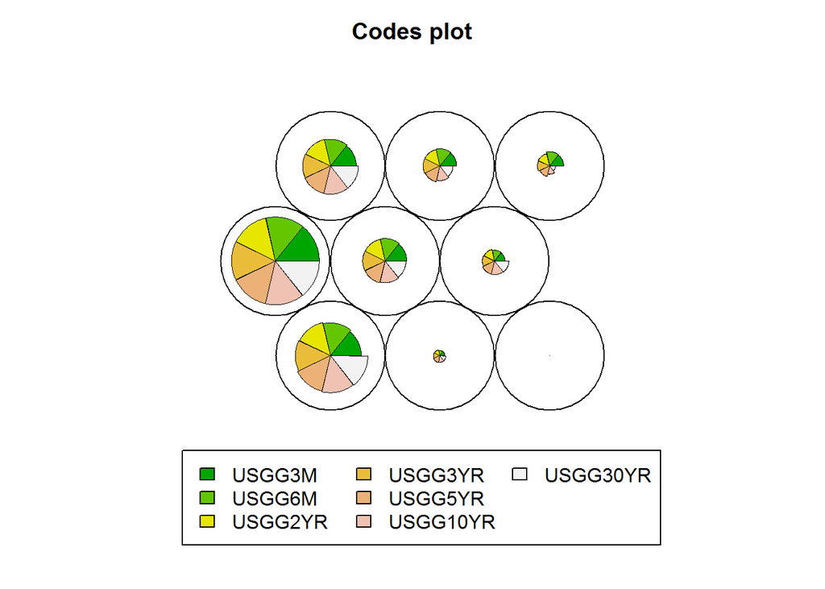

```r
plot(RatesData.som)
```

```r
RatesData.som$codes
```

```
## [[1]]
##         USGG3M     USGG6M    USGG2YR    USGG3YR   USGG5YR  USGG10YR
## V1  9.61358907 10.1692769 11.4870621 11.7238462 12.093799 12.277219
## V2  1.61009825  1.7458953  2.4829403  2.8857717  3.549881  4.368745
## V3  0.09328976  0.1557408  0.5292652  0.8489481  1.542219  2.698524
## V4 13.53993305 13.5129289 14.6151443 14.5203162 14.336487 14.074868
## V5  6.73443881  6.9726561  7.6472629  7.8179556  8.068192  8.345908
## V6  3.23012098  3.3966710  4.3124628  4.7078002  5.499261  6.242617
## V7  8.06393777  8.3026343  9.2596193  9.4448326  9.721749 10.006965
## V8  5.23725658  5.4181861  5.9433635  6.0751496  6.261952  6.464756
## V9  4.40751584  4.5330713  4.5546790  4.5976323  4.661434  4.832399
##     USGG30YR
## V1 12.219339
## V2  5.087153
## V3  3.725894
## V4 13.630947
## V5  8.444895
## V6  6.926526
## V7 10.091524
## V8  6.684310
## V9  5.090901
```

The `grid` parameter defines the number of states and their distribution on the map.

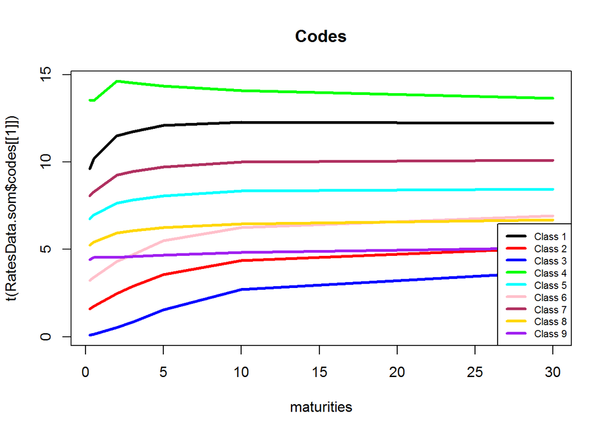

```r
matplot(maturities,t(RatesData.som$codes[[1]]),type="l",lwd=3,lty=1,
        col=c("black","red","blue","green",
              "cyan","pink","maroon","gold","purple"),main="Codes")
legend("bottomright",
       legend=c("Class 1","Class 2","Class 3",
                "Class 4","Class 5","Class 6","Class 7","Class 8","Class 9"),
       lty=1,lwd=3,col=c("black","red","blue","green","cyan",
                         "pink","maroon","gold","purple"),cex=.7)
```

See how clusters are formed from the codes map.

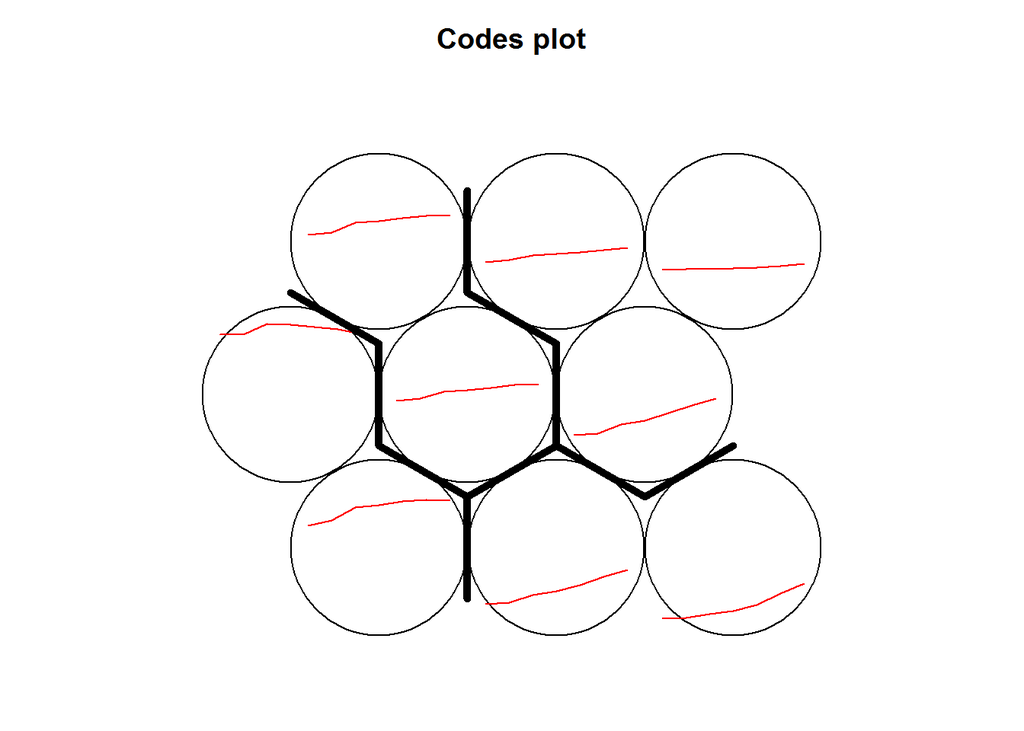

```r
plot(RatesData.som,"codes",codeRendering ="lines")
som.hc <- cutree(hclust(dist(RatesData.som$codes[[1]])), 4)
add.cluster.boundaries(RatesData.som, som.hc)
```

Find clusters of:  
1. Highest curve levels  
2. Lowest curve levels  
3. Below average curve levels  
4. Above average upward-sloping curves

It is better to scale all variables.

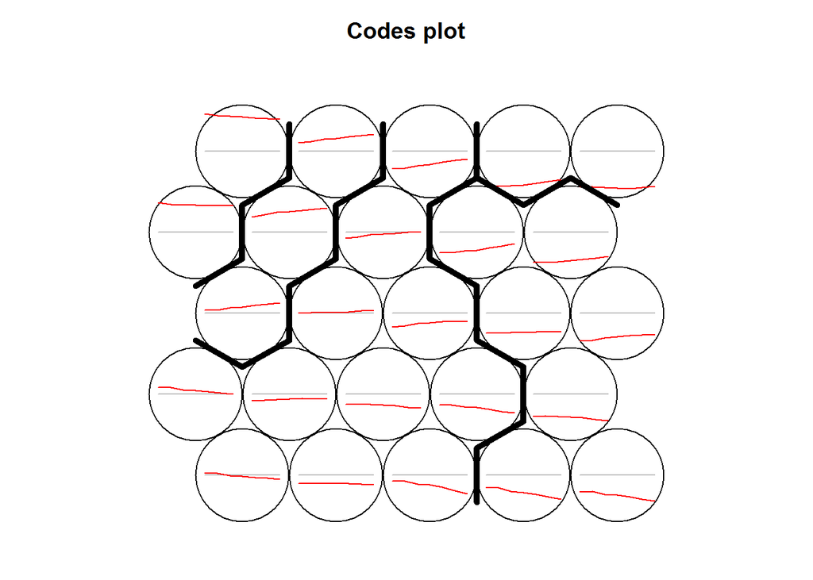

```r
RatesData.som <- som(scale(as.matrix(RatesData)), grid = somgrid(5,5, "hexagonal"))
plot(RatesData.som,"codes",codeRendering ="lines")
som.hc <- cutree(hclust(dist(RatesData.som$codes[[1]])), 5)
add.cluster.boundaries(RatesData.som, som.hc)
```

Describe 5 clusters created on 5x5 map.

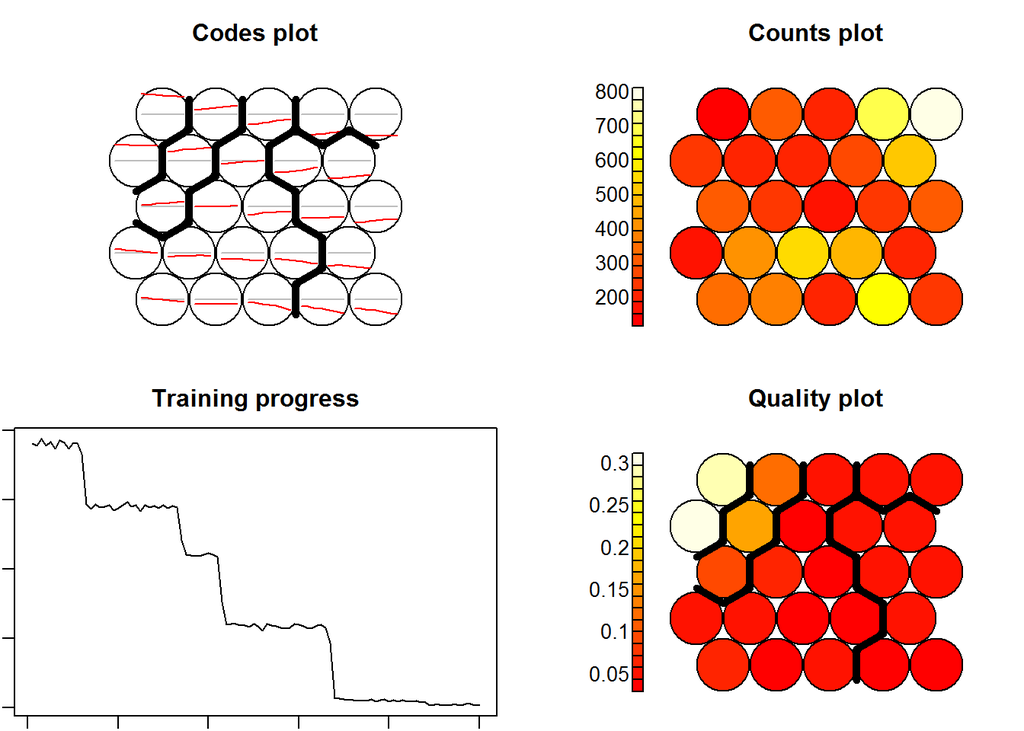

```r
par(mfrow=c(2,2))
plot(RatesData.som,"codes",codeRendering ="lines")
add.cluster.boundaries(RatesData.som, som.hc)

plot(RatesData.som,"counts")
plot(RatesData.som,"changes")
plot(RatesData.som,"quality")
add.cluster.boundaries(RatesData.som, som.hc)
```

```r
par(mfrow=c(1,1))
```

Try fitting the map using different grid sizes. Try to find the best size. Interpret the scenarios.

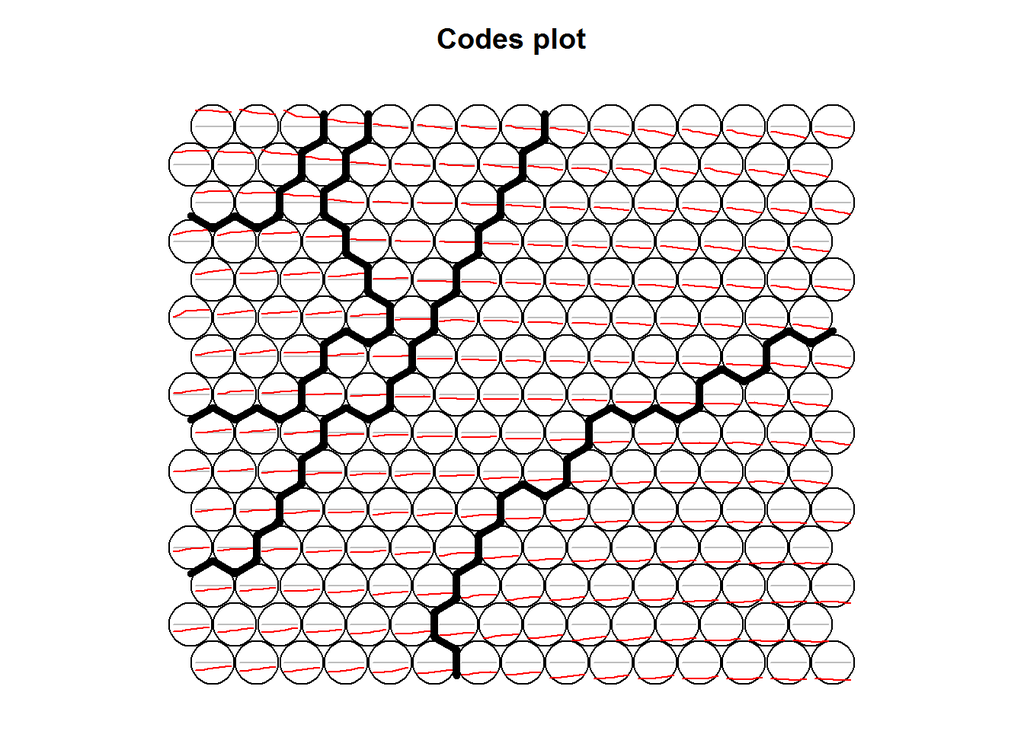

```r
RatesData.som.large <- som(scale(as.matrix(RatesData)), grid = somgrid(15,15, "hexagonal"))
plot(RatesData.som.large,"codes",codeRendering ="lines")
som.hc <- cutree(hclust(dist(RatesData.som.large$codes[[1]])), 5)
add.cluster.boundaries(RatesData.som.large, som.hc)
```

Create codes based on 5 clusters.

```r
som.hc
```

```
##   V1   V2   V3   V4   V5   V6   V7   V8   V9  V10  V11  V12  V13  V14  V15
##    1    1    1    1    1    1    2    2    2    2    2    2    2    2    2
##  V16  V17  V18  V19  V20  V21  V22  V23  V24  V25  V26  V27  V28  V29  V30
##    1    1    1    1    1    1    2    2    2    2    2    2    2    2    2
##  V31  V32  V33  V34  V35  V36  V37  V38  V39  V40  V41  V42  V43  V44  V45
##    1    1    1    1    1    1    2    2    2    2    2    2    2    2    2
##  V46  V47  V48  V49  V50  V51  V52  V53  V54  V55  V56  V57  V58  V59  V60
##    3    3    1    1    1    1    1    2    2    2    2    2    2    2    2
##  V61  V62  V63  V64  V65  V66  V67  V68  V69  V70  V71  V72  V73  V74  V75
##    3    3    1    1    1    1    1    2    2    2    2    2    2    2    2
##  V76  V77  V78  V79  V80  V81  V82  V83  V84  V85  V86  V87  V88  V89  V90
##    3    3    3    1    1    1    1    1    1    2    2    2    2    2    2
##  V91  V92  V93  V94  V95  V96  V97  V98  V99 V100 V101 V102 V103 V104 V105
##    3    3    3    1    1    1    1    1    1    2    2    2    2    2    2
## V106 V107 V108 V109 V110 V111 V112 V113 V114 V115 V116 V117 V118 V119 V120
##    4    4    4    3    3    1    1    1    1    1    1    1    2    2    2
## V121 V122 V123 V124 V125 V126 V127 V128 V129 V130 V131 V132 V133 V134 V135
##    4    4    4    3    3    1    1    1    1    1    1    1    1    2    2
## V136 V137 V138 V139 V140 V141 V142 V143 V144 V145 V146 V147 V148 V149 V150
##    4    4    4    4    4    3    1    1    1    1    1    1    1    1    1
## V151 V152 V153 V154 V155 V156 V157 V158 V159 V160 V161 V162 V163 V164 V165
##    4    4    4    4    3    3    1    1    1    1    1    1    1    1    1
## V166 V167 V168 V169 V170 V171 V172 V173 V174 V175 V176 V177 V178 V179 V180
##    4    4    4    4    3    3    3    1    1    1    1    1    1    1    1
## V181 V182 V183 V184 V185 V186 V187 V188 V189 V190 V191 V192 V193 V194 V195
##    5    5    4    3    3    3    3    1    1    1    1    1    1    1    1
## V196 V197 V198 V199 V200 V201 V202 V203 V204 V205 V206 V207 V208 V209 V210
##    5    5    5    4    3    3    3    3    1    1    1    1    1    1    1
## V211 V212 V213 V214 V215 V216 V217 V218 V219 V220 V221 V222 V223 V224 V225
##    5    5    5    4    3    3    3    3    1    1    1    1    1    1    1
```

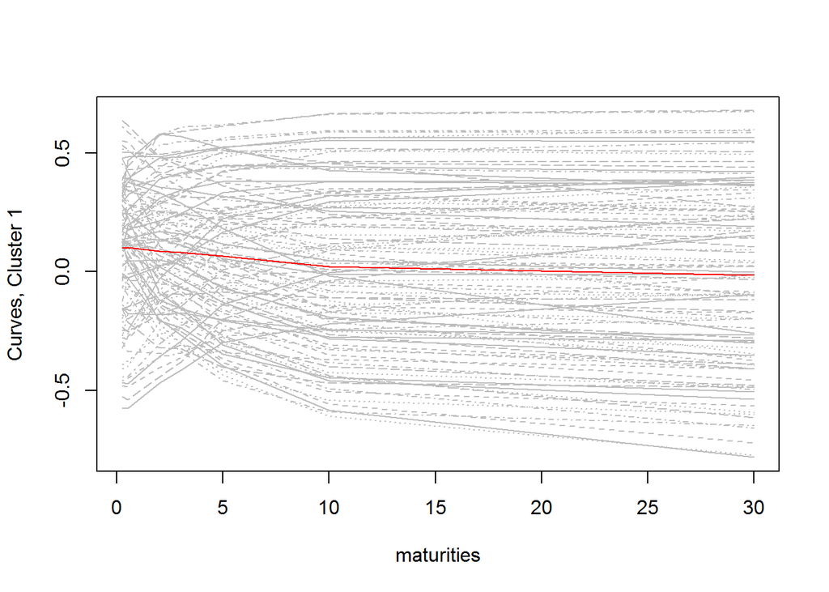

```r
#Cluster 1
Cluster1.code<-apply(subset(RatesData.som.large$codes[[1]],som.hc==1),2,mean)
matplot(maturities,t(subset(RatesData.som.large$codes[[1]],som.hc==1)),type="l",col="grey",ylab="Curves, Cluster 1")
lines(maturities,Cluster1.code,col="red")
```

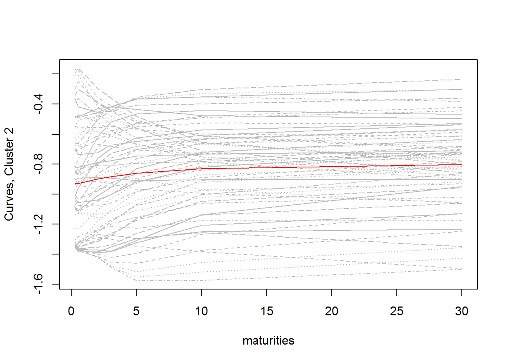

```r
#Cluster 2
Cluster2.code<-apply(subset(RatesData.som.large$codes[[1]],som.hc==2),2,mean)
matplot(maturities,t(subset(RatesData.som.large$codes[[1]],som.hc==2)),type="l",col="grey",ylab="Curves, Cluster 2")
lines(maturities,Cluster2.code,col="red")
```

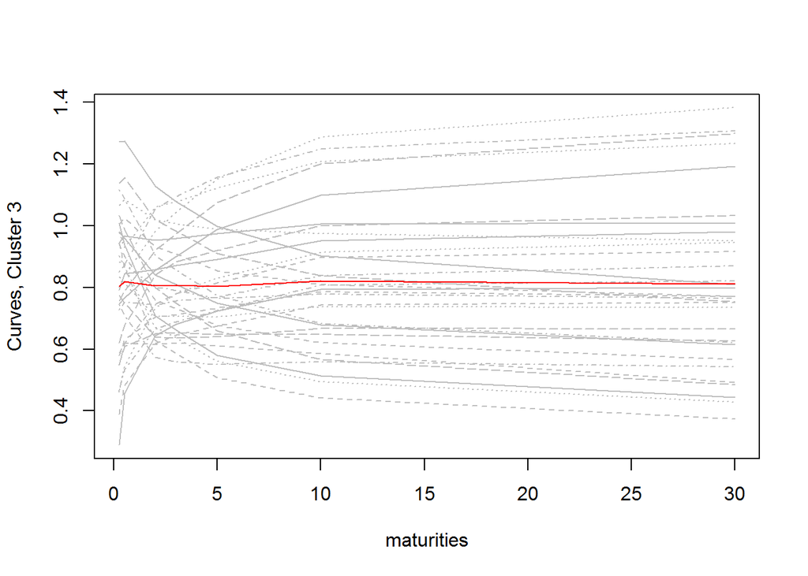

```r
#Cluster 3
Cluster3.code<-apply(subset(RatesData.som.large$codes[[1]],som.hc==3),2,mean)
matplot(maturities,t(subset(RatesData.som.large$codes[[1]],som.hc==3)),type="l",col="grey",ylab="Curves, Cluster 3")
lines(maturities,Cluster3.code,col="red")
```